# Reporting regression results

Extracting model estimates and data structure

Daniela Palleschi

Humboldt-Universität zu Berlin

2024-07-09

# Learning objectives

Today we will…

- run our first linear (mixed) model
- produce model summary tables
- report random effects
- do the same with a Bayesian model

# Resources

# Set-up

## Packages

- we’ll need the following packages for today

```r
pacman::p_load(
  tidyverse,
  lme4,
  broom,
  broom.mixed,
  brms
)
```

## Data

- we’ll need the dataset we’ve been working with

```r
df_lifetime <- readr::read_csv(here::here("data", "tidy_data_lifetime_pilot.csv"),
                               # for special characters
                               locale = readr::locale(encoding = "latin1")
                               ) |>
  mutate_if(is.character,as.factor) |> # all character variables as factor
  filter(type == "critical", # only critical trials
         px != "px3") # this participant had lots of 0's for some reason
```

## Data dictionary

- let’s review the data dictionary

```r
dict_lifetime <- read_csv(
  here::here("data", "tidy_data_lifetime_pilot_dictionary.csv")
)
```

## Model prep

- we want to only have critical items

```r
df_lifetime <-
  df_lifetime |>
  filter(type == "critical") |>
  droplevels()
```

- we want our predictors (`lifetime` and `tense`) to be factors

```r
df_lifetime$lifetime <- as.factor(df_lifetime$lifetime)
df_lifetime$tense <- as.factor(df_lifetime$tense)
```

```r
contrasts(df_lifetime$lifetime)
```

```
       living
dead        0
living      1
```

```r
contrasts(df_lifetime$tense)
```

```
   SF
PP  0
SF  1
```

- we see the default treatment (or ‘dummy’) contrasts here
- to change them:

```r
contrasts(df_lifetime$lifetime) <- c(-0.5, +0.5)
contrasts(df_lifetime$tense) <- c(+0.5, -0.5)
```

```r
contrasts(df_lifetime$lifetime)
```

```
       [,1]
dead   -0.5
living  0.5
```

```r
contrasts(df_lifetime$tense)
```

```
   [,1]
PP  0.5
SF -0.5
```

# Linear regression

```r
lm(
  log(fp) ~ tense * lifetime,
  subset = region == "verb" & ff > 0,
  data = df_lifetime
)
```

```
Call:
lm(formula = log(fp) ~ tense * lifetime, data = df_lifetime,
    subset = region == "verb" & ff > 0)

Coefficients:
     (Intercept)            tense1         lifetime1  tense1:lifetime1
         5.63477           0.03357          -0.10130          -0.08320
```

## Naming conventions

- we want to store our model as an object in the Environment
  - always try to use a prefix that defines what the object is
  - e.g., `fit_`, `mod_`, `lm_`, `glm_`
  - whatever you choose, be consistent within your project

```r
lm_fp <-
  lm(
  log(fp) ~ tense * lifetime,
  subset = region == "verb" & ff > 0,
  data = df_lifetime
)
```

## Model summary

- the most straightforward way to inspect your model and the results is with `summary()`

```r
summary(lm_fp)
```

## Model summary

```
Call:
lm(formula = log(fp) ~ tense * lifetime, data = df_lifetime,
    subset = region == "verb" & ff > 0)

Residuals:
     Min       1Q   Median       3Q      Max
-1.18141 -0.34282  0.00058  0.26923  1.38822

Coefficients:
                 Estimate Std. Error t value Pr(>|t|)
(Intercept)       5.63477    0.01877 300.193  < 2e-16 ***
tense1            0.03357    0.03754   0.894  0.37158
lifetime1        -0.10130    0.03754  -2.698  0.00718 **
tense1:lifetime1 -0.08320    0.07508  -1.108  0.26828
---
Signif. codes:  0 '***' 0.001 '**' 0.01 '*' 0.05 '.' 0.1 ' ' 1

Residual standard error: 0.4374 on 539 degrees of freedom
Multiple R-squared:  0.01712,   Adjusted R-squared:  0.01165
F-statistic: 3.129 on 3 and 539 DF,  p-value: 0.02538
```

## Extracting information

- `lme4` objects contains lots of information
  - navigate to the model object in your Environment and explore the elements
- `nobs(model)` will tell you how many data points were included in the model
- `formula(model)` will give you the model formula

```r
nobs(lm_fp)
```

```
[1] 543
```

```r
formula(lm_fp)
```

```
log(fp) ~ tense * lifetime
```

- want to check which contrasts were used in your model?

```r
lm_fp$contrasts
```

```
$tense
   [,1]
PP  0.5
SF -0.5

$lifetime
       [,1]
dead   -0.5
living  0.5
```

## Model reporting

- when you run your models, you’ll want to also print the output
  - this way you avoid needing to re-run your code to see the results
- for `lme4` models we can use `summary()`
- number of participants in your model

```r
summary(lm_fp)$ngrps["px"]
```

[output not shown]

# Running models reproducibly

- as your models get more computational complex, they can take time to fit
  - sometimes you also run several models in the same script
- with literate programming, we want to be able to produce dynamic reports
  - we don’t want to run our models anew every time we re-render our document!
  - this also might result in different results if e.g., we update a package or R version
  - or if we send the script to somebody else with a different set-up
- ideally, we would have our source code, output (results), *and* the actual model all stored and retrievable

# Model reporting

- when you run your models, you’ll want to also print the output
  - this way you avoid needing to re-run your code to see the results
- for `lme4` models we can use `summary()`

## `broom`

- the `broom` package also contains useful functions for reporting `lme4` models
  - `broom::tidy()` produces the model estimates for our fixed effects

## Publication-ready tables

- we’ve already seen how to produce publication-ready tables
  - TASK: produce a summary of the fixed effects of a model and feed it into our `knitr` and `kableExtra` functions to produce a publication-ready table

# Mixed models

- the assumption of independence is often violated
  - due to multiple observations collected from e.g., the same person or item, language, etc.
- this can lead to the inflation of Type I error (the chance of a false positive)
- to account for this nonindependence of data points, we can used *mixed* models
  - *mixed* because they contain fixed effects (i.e., our predictors at the population-level) as well as *random* effects (group-level overall means and predictor effects)

## `lmer()`

```r
lmer_lifetime <-
  lmer(log(fp)  ~ tense * lifetime +
         (1|px) + (1|item_id),
       subset = region == "verb" & fp > 0,
       data = df_lifetime)
```

## `summary()`

```r
summary(lmer_lifetime)
```

```
Linear mixed model fit by REML ['lmerMod']
Formula: log(fp) ~ tense * lifetime + (1 | px) + (1 | item_id)
   Data: df_lifetime
 Subset: region == "verb" & fp > 0

REML criterion at convergence: 582.5

Scaled residuals:
     Min       1Q   Median       3Q      Max
-2.99792 -0.67159  0.02895  0.67995  2.67790

Random effects:
 Groups   Name        Variance Std.Dev.
 item_id  (Intercept) 0.007012 0.08374
 px       (Intercept) 0.034124 0.18473
 Residual             0.154885 0.39355
Number of obs: 543, groups:  item_id, 80; px, 7

Fixed effects:
                 Estimate Std. Error t value
(Intercept)       5.63161    0.07245  77.736
tense1            0.03794    0.03389   1.120
lifetime1        -0.10308    0.03387  -3.044
tense1:lifetime1 -0.09587    0.06778  -1.414

Correlation of Fixed Effects:
            (Intr) tense1 liftm1
tense1      -0.001
lifetime1    0.000  0.013
tens1:lftm1  0.003  0.002 -0.002
```

## `broom.mixed`

- the `broom.mixed` package also contains useful functions for reporting `lme4` mixed models
  - `broom.mixed::tidy()` produces the model estimates for fixed and random effects
  - if you only want fixed effects, use the argument `effects = "fixed"`
  - if you only want random effects, use the argument `effects = "ran_pars"`

### `tidy()`

```r
tidy_lmer_lifetime <- broom.mixed::tidy(lmer_lifetime)
```

```r
tidy_lmer_lifetime
```

```
# A tibble: 7 × 6
  effect   group    term             estimate std.error statistic
  <chr>    <chr>    <chr>               <dbl>     <dbl>     <dbl>
1 fixed    <NA>     (Intercept)        5.63      0.0724     77.7
2 fixed    <NA>     tense1             0.0379    0.0339      1.12
3 fixed    <NA>     lifetime1         -0.103     0.0339     -3.04
4 fixed    <NA>     tense1:lifetime1  -0.0959    0.0678     -1.41
5 ran_pars item_id  sd__(Intercept)    0.0837   NA          NA
6 ran_pars px       sd__(Intercept)    0.185    NA          NA
7 ran_pars Residual sd__Observation    0.394    NA          NA
```

## `lmerTest`

- is something missing from our model summary?
  - which effects were statistically significant (*p* < .05)?
- calculating *p*-values is not trivial
  - `lme4` doesn’t do it for linear models
- we can use the `lmerTest` package, which also has `lme4`

```r
lmerTest_lifetime <-
  lmerTest::lmer(log(fp)  ~ tense * lifetime +
         (1|px) + (1|item_id),
       subset = region == "verb" & fp > 0,
       data = df_lifetime)
```

```r
tidy_lmerTest_lifetime <- broom.mixed::tidy(lmerTest_lifetime)
```

```r
tidy_lmerTest_lifetime
```

```
# A tibble: 7 × 8
  effect   group    term           estimate std.error statistic     df   p.value
  <chr>    <chr>    <chr>             <dbl>     <dbl>     <dbl>  <dbl>     <dbl>
1 fixed    <NA>     (Intercept)      5.63      0.0724     77.7    6.20  1.65e-10
2 fixed    <NA>     tense1           0.0379    0.0339      1.12 471.    2.63e- 1
3 fixed    <NA>     lifetime1       -0.103     0.0339     -3.04 468.    2.47e- 3
4 fixed    <NA>     tense1:lifeti…  -0.0959    0.0678     -1.41 471.    1.58e- 1
5 ran_pars item_id  sd__(Intercep…   0.0837   NA          NA     NA    NA
6 ran_pars px       sd__(Intercep…   0.185    NA          NA     NA    NA
7 ran_pars Residual sd__Observati…   0.394    NA          NA     NA    NA
```

### Publication-ready tables

- we’ve already seen how to produce publication-ready tables
  - TASK: produce publication-ready tables using `knitr` and `kableExtra` for:
    - a table of the model estimates of the fixed effects of our model
    - a table of the model estimates of the random effects of our model
    - a table of the with both the fixed and random effects
- produce one of these tables as LaTeX code (if you haven’t already)
  - can you then produce this table in Overleaf?

# How to report

- you would typically have a (sub)section called Data Analysis which includes all the steps taken prior to inspecting your results
  - i.e., how you prepared and analysed your data
  - this should be information stated in a pre-registration but in the past tense
- this would typically be followed by a Results section
  - containing the results from these cleaning/analysis steps

## Results

- this would be followed by a section called Results, which reports e.g.,
  - the number of participants and trials ex-/included in analyses
  - possibly raw means and 95% confidence intervals
  - model formula
  - information about the number of observations per model
- a structure overview of model results

## Example model report

```markdown
An effect of *lifetime* was found in first-pass reading times at the verb region (Est = `r signif(tidy_lmerTest_lifetime$estimate[tidy_lmer_lifetime$term=="lifetime1"],2)`, *t* = `r signif(tidy_lmerTest_lifetime$statistic[tidy_lmer_lifetime$term=="lifetime1"],2)`, *p* = `r signif(tidy_lmerTest_lifetime$p.value[tidy_lmer_lifetime$term=="lifetime1"],2)`). A significant effect of *tense* was not found found (Est = `r signif(tidy_lmerTest_lifetime$estimate[tidy_lmer_lifetime$term=="tense1"],2)`, *t* = `r signif(tidy_lmerTest_lifetime$statistic[tidy_lmer_lifetime$term=="tense1"],2)`, *p* = `r signif(tidy_lmerTest_lifetime$p.value[tidy_lmer_lifetime$term=="tense1"],2)`), nor an interaction of *lifetime* and *tense* (Est = `r signif(tidy_lmerTest_lifetime$estimate[tidy_lmer_lifetime$term=="tense1:lifetime1"],2)`, *t* = `r signif(tidy_lmerTest_lifetime$statistic[tidy_lmer_lifetime$term=="tense1:lifetime1"],2)`, *p* = `r signif(tidy_lmerTest_lifetime$p.value[tidy_lmer_lifetime$term=="tense1:lifetime1"],2)`).
```

## Output

> An effect of *lifetime* was found in first-pass reading times at the verb region (Est = -0.1, *t* = -3, *p* = 0.0025). A significant effect of *tense* was not found found (Est = 0.038, *t* = 1.1, *p* = 0.26), nor an interaction of *lifetime* and *tense* (Est = -0.096, *t* = -1.4, *p* = 0.16).

# Bayesian models

- this is an incredibly quick introduction to Bayesian linear regression
  - there is a lot of information that I’m glossing over
- the point here is to expose you to (potentially) your first Bayesian model
  - and to see how similar the input and output is to frequentist models

## `brms`

- `Stan` is a language for producing Bayesian models
- `brms` is an R-user-friendly package to fit Bayesian models with `Stan` in the background
  - the function `brm()` can be used to fixed mixed models
- it doesn’t have the `subset` argument, so let’s first filter our data accordingly

```r
df_lifetime_verb <-
  df_lifetime |>
  filter(region == "verb",
         fp > 0)
```

## `brm()`

```r
brm_fp <-
  brm(fp ~ tense * lifetime,
    family = lognormal(),
    data = df_lifetime_verb)
```

## Saving our model

- `brms` models have a nice argument where you can specify where to save a model directly: `file =`
  - this is extremely useful as your models get more complex, because Bayesian models especially can take a long time to run

```r
brm_fp <-
  brm(fp ~ tense * lifetime,
    family = lognormal(),
    data = df_lifetime_verb,
    file = here::here("models", "brm_fp"))
```

## Mixed models in `brm()`

- we can use the same function, just specify random effects

```r
brm_fp <-
  brm(fp ~ tense * lifetime +
        (1|item) + (1|px),
    family = lognormal(),
    data = df_lifetime_verb,
    file = here::here("models", "brm_fp"))
```

```r
summary(brm_fp)
```

```
 Family: lognormal
  Links: mu = identity; sigma = identity
Formula: fp ~ tense * lifetime
   Data: df_lifetime_verb (Number of observations: 543)
  Draws: 4 chains, each with iter = 2000; warmup = 1000; thin = 1;
         total post-warmup draws = 4000

Regression Coefficients:
                 Estimate Est.Error l-95% CI u-95% CI Rhat Bulk_ESS Tail_ESS
Intercept            5.63      0.02     5.60     5.67 1.00     4507     3386
tense1               0.03      0.04    -0.04     0.11 1.00     5252     3241
lifetime1           -0.10      0.04    -0.17    -0.03 1.00     4313     3173
tense1:lifetime1    -0.08      0.07    -0.23     0.07 1.00     5040     3227

Further Distributional Parameters:
      Estimate Est.Error l-95% CI u-95% CI Rhat Bulk_ESS Tail_ESS
sigma     0.44      0.01     0.41     0.47 1.00     5471     3106

Draws were sampled using sampling(NUTS). For each parameter, Bulk_ESS
and Tail_ESS are effective sample size measures, and Rhat is the potential
scale reduction factor on split chains (at convergence, Rhat = 1).
```

- the output is the same…why’s that?
  - when we specify `file =`, `brms` will first look to see if such a file already exists
  - if it does, it simply loads in that model rather than fitting the model
  - the downside is that it doesn’t check if the model formula has changed, so we might not be fitting the model at all!
- to work around this, either
  - delete the file with the same name, if you’re *sure* you want to overwrite it
  - change the filename (which I suggest always matches the object name in your script)
- we’ll do the latter

```r
brm_fp_mixed <-
  brm(fp ~ tense * lifetime +
        (1|item_id) + (1|px),
    family = lognormal(),
    data = df_lifetime_verb,
    file = here::here("models", "brm_fp_mixed"))
```

```r
summary(brm_fp_mixed)
```

```
 Family: lognormal
  Links: mu = identity; sigma = identity
Formula: fp ~ tense * lifetime + (1 | item_id) + (1 | px)
   Data: df_lifetime_verb (Number of observations: 543)
  Draws: 4 chains, each with iter = 2000; warmup = 1000; thin = 1;
         total post-warmup draws = 4000

Multilevel Hyperparameters:
~item_id (Number of levels: 80)
              Estimate Est.Error l-95% CI u-95% CI Rhat Bulk_ESS Tail_ESS
sd(Intercept)     0.07      0.03     0.01     0.13 1.00     1004     1132

~px (Number of levels: 7)
              Estimate Est.Error l-95% CI u-95% CI Rhat Bulk_ESS Tail_ESS
sd(Intercept)     0.24      0.10     0.12     0.49 1.00      972     1262

Regression Coefficients:
                 Estimate Est.Error l-95% CI u-95% CI Rhat Bulk_ESS Tail_ESS
Intercept            5.63      0.10     5.42     5.83 1.00     1104     1329
tense1               0.04      0.03    -0.03     0.11 1.00     6820     2958
lifetime1           -0.10      0.03    -0.17    -0.04 1.00     7347     2785
tense1:lifetime1    -0.10      0.07    -0.23     0.04 1.00     8084     2718

Further Distributional Parameters:
      Estimate Est.Error l-95% CI u-95% CI Rhat Bulk_ESS Tail_ESS
sigma     0.40      0.01     0.37     0.42 1.00     3793     2636

Draws were sampled using sampling(NUTS). For each parameter, Bulk_ESS
and Tail_ESS are effective sample size measures, and Rhat is the potential
scale reduction factor on split chains (at convergence, Rhat = 1).
```

# Plotting our brms model

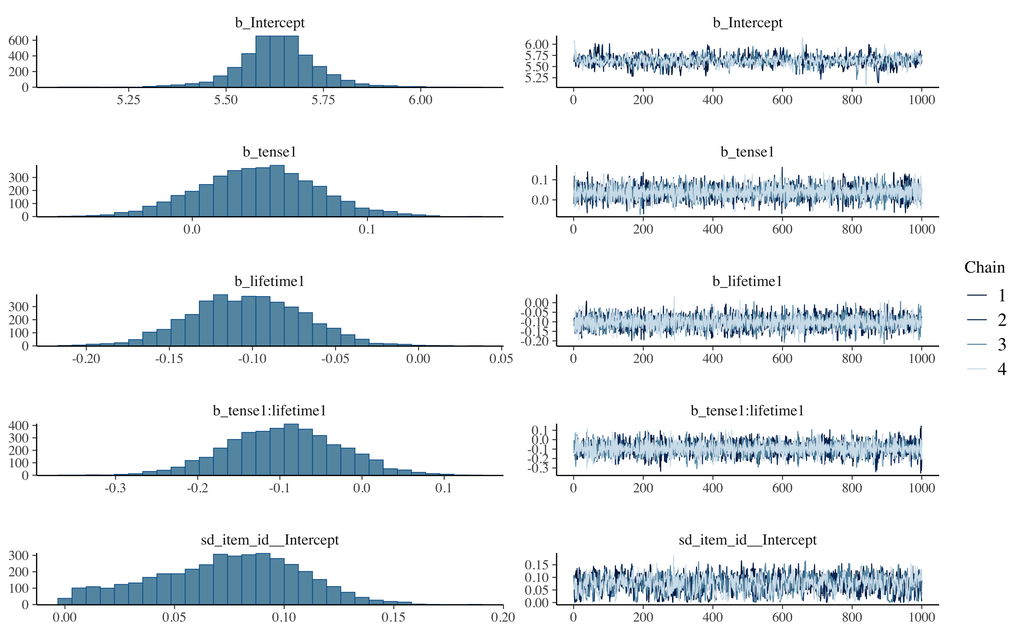

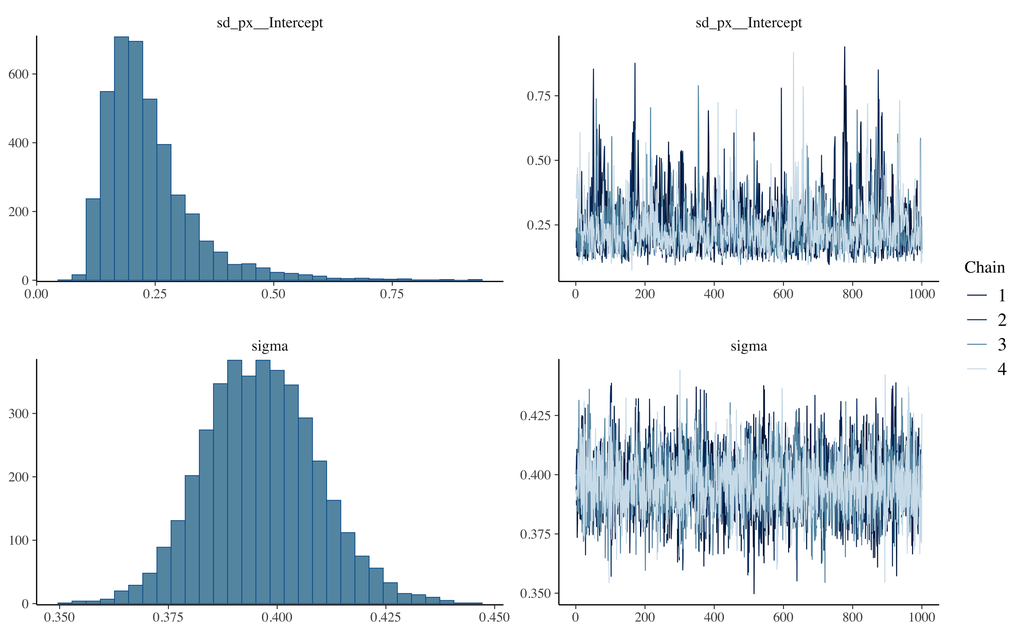

```r
plot(brm_fp_mixed)
```

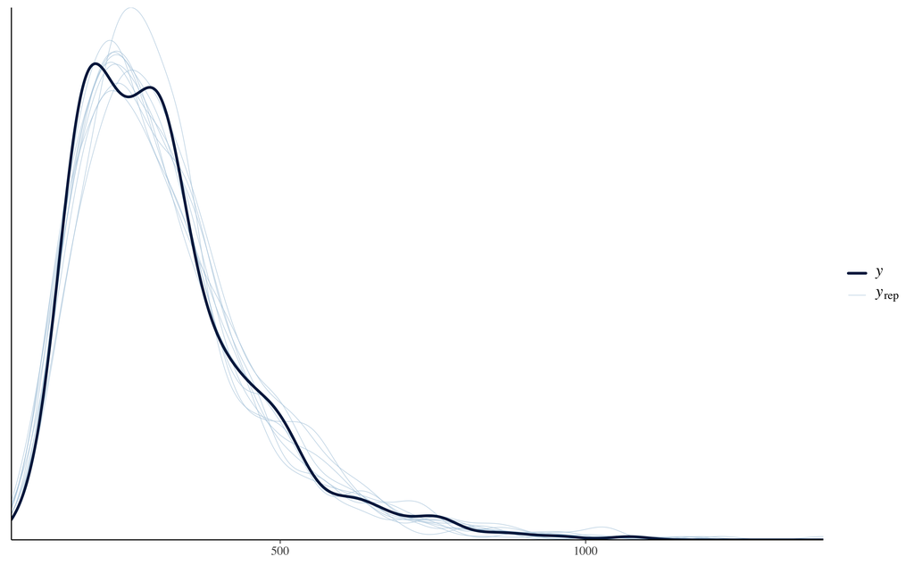

```r
pp_check(brm_fp_mixed)
```

# Under the hood: `brms`

## Understanding our model

- some of the same functions apply to `brms` models

```r
formula(brm_fp)
```

```
fp ~ tense * lifetime
```

```r
nobs(brm_fp)
```

```
[1] 543
```

```r
summary(brm_fp)
```

## Understanding our model

```
 Family: lognormal
  Links: mu = identity; sigma = identity
Formula: fp ~ tense * lifetime
   Data: df_lifetime_verb (Number of observations: 543)
  Draws: 4 chains, each with iter = 2000; warmup = 1000; thin = 1;
         total post-warmup draws = 4000

Regression Coefficients:
                 Estimate Est.Error l-95% CI u-95% CI Rhat Bulk_ESS Tail_ESS
Intercept            5.63      0.02     5.60     5.67 1.00     4507     3386
tense1               0.03      0.04    -0.04     0.11 1.00     5252     3241
lifetime1           -0.10      0.04    -0.17    -0.03 1.00     4313     3173
tense1:lifetime1    -0.08      0.07    -0.23     0.07 1.00     5040     3227

Further Distributional Parameters:
      Estimate Est.Error l-95% CI u-95% CI Rhat Bulk_ESS Tail_ESS
sigma     0.44      0.01     0.41     0.47 1.00     5471     3106

Draws were sampled using sampling(NUTS). For each parameter, Bulk_ESS
and Tail_ESS are effective sample size measures, and Rhat is the potential
scale reduction factor on split chains (at convergence, Rhat = 1).
```

# Citing resources

- you should cite the packages you used to fit your models
  - as well as other package versions used (but `SessionInfo()` also takes care of this)
- to cite packages in-text, you can first extract the citation: with

```r
citation(package = "brms")
```

```
  Paul-Christian Bürkner (2017). brms: An R Package for Bayesian
  Multilevel Models Using Stan. Journal of Statistical Software, 80(1),
  1-28. doi:10.18637/jss.v080.i01

Paul-Christian Bürkner (2018). Advanced Bayesian Multilevel Modeling
with the R Package brms. The R Journal, 10(1), 395-411.
doi:10.32614/RJ-2018-017

Paul-Christian Bürkner (2021). Bayesian Item Response Modeling in R
with brms and Stan. Journal of Statistical Software, 100(5), 1-54.
doi:10.18637/jss.v100.i05

To see these entries in BibTeX format, use 'print(<citation>,
bibtex=TRUE)', 'toBibtex(.)', or set
'options(citation.bibtex.max=999)'.
```

- or as BibTeX citation:

```r
print(citation(package = "brms"), bibtex=TRUE)
```

```
  Paul-Christian Bürkner (2017). brms: An R Package for Bayesian
  Multilevel Models Using Stan. Journal of Statistical Software, 80(1),
  1-28. doi:10.18637/jss.v080.i01

A BibTeX entry for LaTeX users is

  @Article{,
    title = {{brms}: An {R} Package for {Bayesian} Multilevel Models Using {Stan}},
    author = {Paul-Christian Bürkner},
    journal = {Journal of Statistical Software},
    year = {2017},
    volume = {80},
    number = {1},
    pages = {1--28},
    doi = {10.18637/jss.v080.i01},
    encoding = {UTF-8},
  }

Paul-Christian Bürkner (2018). Advanced Bayesian Multilevel Modeling
with the R Package brms. The R Journal, 10(1), 395-411.
doi:10.32614/RJ-2018-017

A BibTeX entry for LaTeX users is

  @Article{,
    title = {Advanced {Bayesian} Multilevel Modeling with the {R} Package {brms}},
    author = {Paul-Christian Bürkner},
    journal = {The R Journal},
    year = {2018},
    volume = {10},
    number = {1},
    pages = {395--411},
    doi = {10.32614/RJ-2018-017},
    encoding = {UTF-8},
  }

Paul-Christian Bürkner (2021). Bayesian Item Response Modeling in R
with brms and Stan. Journal of Statistical Software, 100(5), 1-54.
doi:10.18637/jss.v100.i05

A BibTeX entry for LaTeX users is

  @Article{,
    title = {Bayesian Item Response Modeling in {R} with {brms} and {Stan}},
    author = {Paul-Christian Bürkner},
    journal = {Journal of Statistical Software},
    year = {2021},
    volume = {100},
    number = {5},
    pages = {1--54},
    doi = {10.18637/jss.v100.i05},
    encoding = {UTF-8},
  }
```

- then copy it to your `.bib` file, add a citation reference key (e.g., `burkner_bayesian_2021`), and cite it in-text with `@burkner_bayesian_2021`, which will be formatted as Bürkner (2021)
  - alternatively, save the package reference in Zotero and access it using `rbbt`
  - e.g., copy the DOI then find the Zotero button for ‘Add Item by Identifier’

# Learning objectives 🏁

Today we…

- ran our first linear (mixed) model
- produced model summary tables
- reported random effects
- did the same with a Bayesian model ✅

# References

Bürkner, P.-C. (2021). Bayesian Item Response Modeling in *R* with **Brms** and *Stan*. *Journal of Statistical Software*, *100*(5). https://doi.org/10.18637/jss.v100.i05